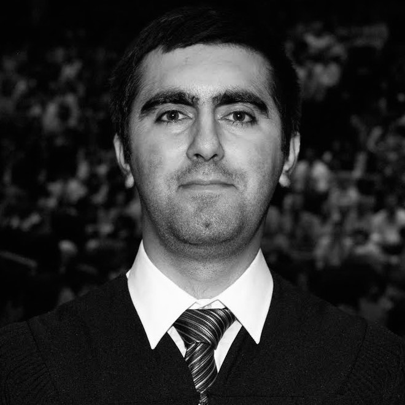

# Samir Musali

Hi, I’m Samir Musali, a highly skilled software engineer with over 6 years of industry experience building and improving new integrations, creating and maintaining customer-facing tools and libraries, automating provisioning processes, and optimizing scripts. I have demonstrated proficiency in building SLO-based Alerting Policies and Dashboards around critical API endpoints, automating GCP Monitoring resources using Terraform, leading projects, developing new integrations, maintaining and improving customer-facing tools and libraries, and architected CI/CD pipelines.

I have a solid academic background, including an Honours Bachelor of Computer Science from the University of Waterloo and a current pursuit of a Master of Arts in Innovation and Technology Management at the University of Tartu. I have also earned certificates from Coursera and DataCamp, including Machine Learning, Software Product Management, and Data Analysis.

As a results-driven software engineer, I am passionate about developing and improving software solutions. I have excellent communication skills and collaborate with teams to achieve project goals. I am a motivated and experienced professional passionate about leveraging my skills and experience to drive innovation, create value, and achieve business goals. I am a strong communicator, problem-solver, and team player, always seeking new challenges and opportunities to apply my knowledge and expertise in a dynamic and exciting environment.